# BSAN2204

Tutorial 9

Dealing with Missing Data

## Today’s goals

We will complete the following in today’s session:

1. Using descriptive statistics to count missing data in `training_data`
2. Visualise missing data in `training_data`
3. Perform a MCAR test for continuous variables in `training_data`
4. Impute missing data in `training_data`
5. Report results from pooled regression using imputed `training_data`

## Why is data missing?

Real world datasets are rarely “complete”. Recall that the structure of a dataset in its simplest form comprises rows (observations) and columns (variables). The cells of a dataset contain values. When a value not available at at the intersection of a particular row and column, it is said to be “missing”.

In `R` the way these values are recorded as missing will to an extent us the reason it is missing. For example, if the value is `NA` the value is not there (and maybe never was), but if it is `NaN` the value is missing do to a calculation error.

Whatever the reason, we need to decide how to deal with these missing values.

## How to deal with missing data?

Before we deal with missing data we need to understand *how* (not why) the data is missing. If there are patterns in the ways data are missing, simply removing observations with missing data risks introducing biases to the analysis.

Methods of simple imputation (e.g., replacing missing values with the mean value of the available data) may worsen the situation, not improve it, as this would constrain the variance of the data.

Dealing with missing data is a technical challenge, but also poses an ethical dilemma.

## Multiple imputation

Using multiple imputation is a process through which multiple different “complete” datasets are generated. The values in each imputed dataset are randomly sampled from the distribution of the observed data, such that the imputed values follow the same distribution as the observed data.

As with other random processes in `R`, using `set.seed()` during multiple imputation ensures that the outputs can be reliably repeated.

Regression models can be run on each imputed dataset is analysed separately. The `estimates` and `p-values` are pooled together (averaged). Dealing with missing data this way reduces the uncertainty introduced by the fact that some observations have missing values.

## Missing data in the MSD `training_data`

Before we attempt to replace missing data through multiple imputation, we will first see what the extent of missing data is using descriptive statistics.

`sum(is.na(x))` counts the number of values in the data frame `x` for which `is.na() == TRUE`.

`mean(is.na(x))` returns the proportion of the values in the data frame `x` for which `is.na() == TRUE`.

The results of these little checks are useful to report as text using inline code in the *Predictive Analytics Report (A2)*, at the start of the section on *Dealing with Missing Data*.

## Descriptive statistics for missing data

To count the total number of **missing** values in the `training_data` across all variables and all observations:

```r
sum(is.na(training_data))
```

```
[1] 13990
```

To count the number of observations (rows) of the `training_data` which have **complete** data across all variables, we can use:

```r
sum(complete.cases(training_data))
```

```
[1] 2117
```

To summarise the proportion of **missing** data within a single variable (column) of the `training_data`, we can use:

```r
mean(is.na(training_data$year))
```

```
[1] 0.4798
```

## Visualising missing data

We gain much more insight into both the extent and patterns of missingness in a data frame by visualising missing data. The `VIM` package provides a series of data visualisation functions useful for this purpose.

The visualisations demonstrated in the lecture include:

- `aggr()`
- `marginplot()`
- `matrixplot()`

## Aggregate plot

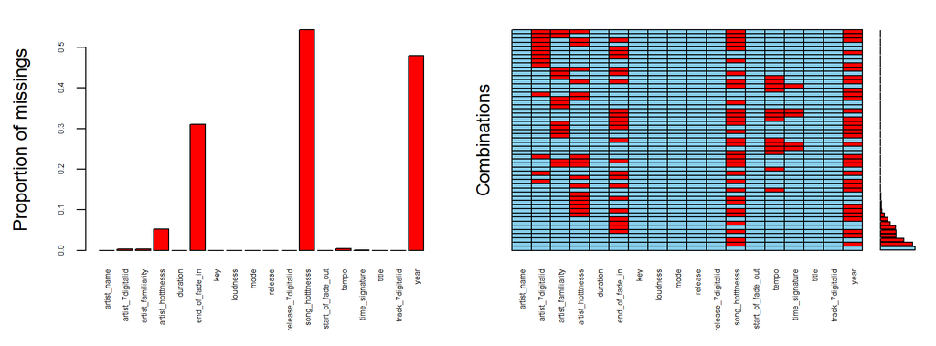

```r
library(VIM)
aggr(training_data, cex.axis = 0.5)
```

Include *all variables* in this plot so that missingness in the entirety of your subset can be seen. This plot also usually needs us to adjust the font size of the axis labels, which we can achieve by setting `cex.axis = 0.5` (0.5 the default size).

## Margin plot

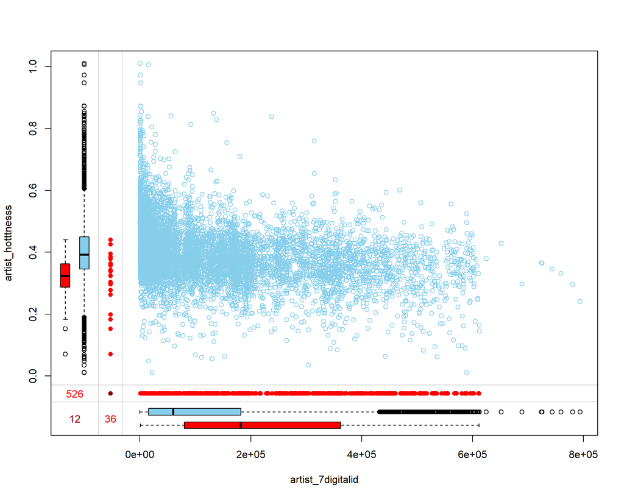

```r
marginplot(training_data[c("artist_7digitalid",
                        "artist_hotttnesss")])
```

This plot produces a bivariate scatter plot with box plots in the margins for two variables to help us see whether there is any structure to missingness.

We should use insights drawn from the `aggr()` plot to inform us which pairs of variables to explore using `marginplot()`, i.e., to select pairs which are shown to be commonly missing together.

Tip: Use `par(mfrow())` to panel multiple margin plots together.

Artist ID and Artist Hotness have been chosen here for *demonstrative purposes* only. You should choose (with justifications) your own pair(s) of variables to visualise.

## Matrix plot

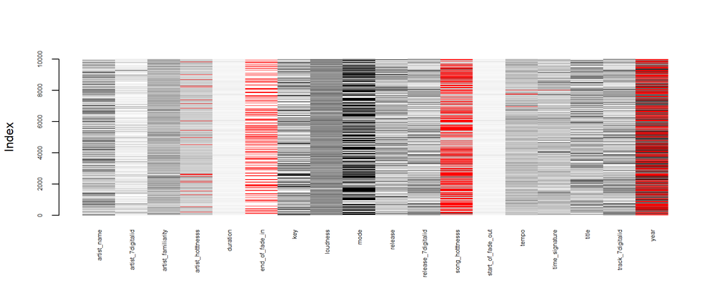

```r
matrixplot(training_data, cex.axis = 0.5)
```

This heat map style plot showing missingness across all rows and columns of the data. Exploring different matrix plots sorted by different variables using `sortby =` can help to reveal patterns in your training data subset.

## MCAR test

Use the `mcar_test()` function from `naniar` to formally test whether the missingness observed is MCAR (Missing Completely at Random) or not.

It is important to only include **continuous** variables in the `mcar_test()`.

Exclude ID variables, character variables and factors.

The test relies on assumptions of multivariate normality in the relationships between variables. Including non-numeric data violates this assumption and may lead to biased results

## MCAR test in `training_data`

```r
library(naniar)
library(dplyr)

continuous_variables <- c("artist_familiarity",
                          "artist_hotttnesss",
                          "duration",
                          "end_of_fade_in",
                          "loudness",
                          "song_hotttnesss",
                          "start_of_fade_out",
                          "tempo",
                          "year")

mcar_test(training_data[ , continuous_variables]) |>
  mutate(
    statistic = formatC(statistic, format = "f", digits = 3),
    p.value   = ifelse(p.value < 0.05, "< 0.05",
                       formatC(p.value, format = "f", digits = 3))) |>
    kable()
```

| statistic | df | p.value | missing.patterns |
| --- | --- | --- | --- |
| 4228.780 | 217 | < 0.05 | 35 |

## Interpreting `mcar_test()`

The `p.value` from the output of `mcar_test()` indicates the probability of observing the patterns of missingness seen in the data if the missing values were truly missing completely at random (MCAR).

A low p value (`< 0.05`) is evidence *against* MCAR, it suggests that missingness depends on observed or unobserved data (i.e., it is MAR or MNAR).

A high p value (`> 0.05`) suggests that the missing values are likely to be MCAR.

## To impute or not to impute?

We should almost always impute, but the case for imputation is especially strong when the missingness affects variables that are central to inference or prediction, and when the mechanism is plausibly MAR (Missing At Random), i.e., when the results of a `mcar_test()` has a low `p value` (p < .05).

Even when there is evidence to suggest the missing data is MCAR, i.e., when the `p value` from the `mcar_test()` is high (> .05), imputation can be performed but is not as necessary. It is only recommended to omit observations due to missingness when the proportion of observations missing data is low (e.g., when the proportion of missing data in the whole dataset given by `mean(is.na(x))` is less than 5%).

## Imputation model vs Regression model

The imputation model is what `mice()` uses to fill in missing values.

The specification of the imputation model does not need match your regression model. That is, the variables to impute does not need to be the same list as those entered into your `lm()` model (nor do they need to be same as those tested using `mcar_test()`).

In almost all cases, the more variables available to include in the imputation model the better (i.e., there is no penalty for lacking parsimony, unlike regression). The only variables which should be exluded from the `mice()` function are character variables and unique identifiers.

See `?mice::mice` for complete documentation details.

## Using `mice()`

```r
mice_variables <- c("artist_familiarity",
                    "artist_hotttnesss",
                    "duration",
                    "end_of_fade_in",
                    "key", "loudness",
                    "mode",
                    "song_hotttnesss",
                    "start_of_fade_out",
                    "tempo",
                    "time_signature",
                    "year")

library(mice)
imputed_data <- mice(training_data[, mice_variables])
```

Make sure to set `results='hide'` for the R chunk in your `.Rmd` which includes the `mice()` function, else the iteration summary will be unnecessarily included as output in your document.

Running `mice()` can take some time. Be patient!

With `training_data` of `n = 10,000` it takes approximately 1 minute.

## Running `mice()`

`mice()` runs an iterative process. For each variable with missing data, it builds a model using the *all* the other available variables at input variables, predicts the missing values, and cycles through this many times until the imputations the means/variances are similar across each dataset.

The end result is a list object in the `R` environment that stores each of the multiple imputations. The default number of multiple imputed datasets created is 5, hence the list objects stores 5 “complete” data frames that have had missing data replaced. Each of the 5 imputed datasets varies slightly.

In your R Markdown (`.Rmd`) file you should set the option `results='hide'` for this R chunk to prevent the list of iterations from printing to your document.

## Regression with Multiple Imputation

The next step is to fit a regression to each imputed dataset, and then pool all those separately run regression models. Use the **best model** specification from your model catalogue explored using regression.

The `with()` function is used to iterate across each data frame in the list object, applying the same `lm()` model to each.

```r
fitted_models <- with(imputed_data, lm(song_hotttnesss ~ end_of_fade_in
                                       + duration
                                       + year
                                       + I(year^2)
                                       + duration:year))
pooled_models <- pool(fitted_models)
```

The `lm()` model written out above corresponds to `m4` in the regression tutorial, which had the best adjusted $R^2$ value.

## Reporting pooled regresion

Just like we saw with regression, we should **curate** the outputs to include in our document for reporting. To be very concise, the only essential values to include are the `estimates` and their associated `p values`, which can be selected by naming these columns inside square brackets `[]`.

The output stored after using `<- pool()` is *not* a `lm()` object so we cannot use `modelsummary()`. It is data frame, so we will pipe through to `kable()`.

```r
summary(pooled_models)[ , c("term", "estimate", "p.value")] |>
  kable(digits = 4, caption = "Pooled Regression")
```

## Pooled regression output

Pooled Regression

| term | estimate | p.value |
| --- | --- | --- |
| (Intercept) | 134.5288 | 0.0110 |
| end_of_fade_in | 0.0011 | 0.0031 |
| duration | 0.0041 | 0.1232 |
| year | -0.1369 | 0.0107 |
| I(year^2) | 0.0000 | 0.0103 |
| duration:year | 0.0000 | 0.1201 |

## Model fit measures

The pooled regression includes `estimates` and `p-values` but not model fit measures because the pooling process only pools estimates. The average adjusted $R^2$ from the pooled models can be extracted and reported in text using inline code with:

```r
paste0(
  mean(pooled_models$glanced$adj.r.squared)
  |> round(4) * 100, "%")
```

```
[1] "1.6%"
```

Technically speaking, an *averaged* adjusted $R^2$ from across *multiple models* is not a formal measure of model fit in the context of multiple imputation. However, it does provide a general sense of whether imputing missing values improves predictive accuracy on average, especially when compared to models that have omitted observations due to missingness.

## Comparing pooled and intial regression

The average adjusted $R^2$ across `pooled_models` is 1.6% whilst adjusted $R^2$ of `m4` (estimated in the regression tutorial) was 3.16%.

The pooled regression (averaged) adjusted $R^2$ can be lower than the model with missing data omitted, but the pooled regression `estimates` will always be *less biased* because they deal with missing data through imputation process which avoid the bias introduced by omitting observations due to missingness.

In your `.Rmd` you will have already have the results from your previous models saved as model objects in your environment. Either compare them in text using inline code (as per this slide) or create a comparison table.

## When to omit missing data?

By default, regression models in `lm()` drop any rows with missing values, since all variables must be complete for estimation. As a result, the effective sample size is limited by the variable with the greatest amount of missing data. The output from `summary()` reports the number of observations deleted from the analysis.

```
Residual standard error: 0.1547 on 2156 degrees of freedom (7839 observations deleted due to missingness)
```

To delete such observations before the analysis could be done using `na.omit()` or `complete.cases()` but this should only be used if you are convinced missing data in the dataset *is MCAR* based on evidence generated from visualising patterns of missingness, and from a formal test of whether the missingness is MCAR using `mcar_test()`.

## Using `na.omit()`

```r
training_data_na_omit <- na.omit(training_data)

m4_na_omit <- lm(song_hotttnesss ~ end_of_fade_in + duration + year + I(year^2) + duration:year,
                 data = training_data_na_omit)

summary(m4_na_omit)
```

```
Call:
lm(formula = song_hotttnesss ~ end_of_fade_in + duration + year +
    I(year^2) + duration:year, data = training_data_na_omit)

Residuals:
     Min       1Q   Median       3Q      Max
-0.33514 -0.10536 -0.00487  0.10805  0.52448

Coefficients:
                 Estimate Std. Error t value Pr(>|t|)
(Intercept)     3.595e+02  8.079e+01   4.451 9.01e-06 ***
end_of_fade_in  6.193e-03  1.345e-03   4.604 4.39e-06 ***
duration        9.928e-03  6.524e-03   1.522    0.128
year           -3.639e-01  8.133e-02  -4.474 8.08e-06 ***
I(year^2)       9.217e-05  2.047e-05   4.503 7.06e-06 ***
duration:year  -4.974e-06  3.263e-06  -1.524    0.128
---
Signif. codes:  0 '***' 0.001 '**' 0.01 '*' 0.05 '.' 0.1 ' ' 1

Residual standard error: 0.1517 on 2111 degrees of freedom
Multiple R-squared:  0.03607,   Adjusted R-squared:  0.03378
F-statistic:  15.8 on 5 and 2111 DF,  p-value: 2.663e-15
```

## Imputing in the test data?

In the next session, we will run model validation using the `test_data`. As part of this process, we will impute missing data in the `test_data`.

You might be tempted to ask if we could avoid doing the imputation process twice by first imputing data in the full data prior to splitting the sample into the training and test data. This must be avoided.

It is important to keep the imputation process in the `training_data` and `test_data` **separate** otherwise there is “data leakage” between the two.

Thank you!